# EarthqVis

Mot Hakimi

2023-03-24

This package is designed to visualize earthquake data.

## eq_location_clean

**Description** *eq_location_clean* Make Location name nicer

**Usage** eq_location_clean(data)

**Arguments** *data*: A dataset

**Value** cleaned dataset

**Examples**

```r
readr::read_delim(raw_data,
                  delim = "\t") %>%
                      eq_location_clean()
```

## eq_clean_data

**Description** *eq_clean_data* Curate data

**Usage** eq_clean_data(data)

**Arguments** *data*: A dataset

**Value** curated dataset

**Examples**

```r
readr::read_delim(raw_data,
                  delim = "\t") %>%
                      eq_location_clean()
```

## eq_create_label

**Description** *eq_create_label* make label for popup on the map

**Usage** eq_create_label(data)

**Arguments** *data*: A dataset

**Value** a list of labels consisting of Location, Number of Deaths and Magnitude for each earthquake

**Examples**

```r
readr::read_delim(raw_data,
                  delim = "\t") %>%
       eq_location_clean()%>%
       dplyr::mutate(popup_text = eq_create_label(.))
```

## eq_map

**Description** *eq_map* Show Points on map

**Usage** eq_map(data, annot_col)

**Arguments** *data*: A dataset

*annot_col*: selected column for showing in pop-up

**Value** show earthquake points on maps

**References** https://rstudio.github.io/leaflet/markers.html

**Examples**

```r
readr::read_delim(raw_data,
                  delim = "\t") %>%
       eq_clean_data() %>%
    dplyr::filter(COUNTRY == "MEXICO" & lubridate::year(DATE) >= 2000) %>%
    dplyr::mutate(popup_text = eq_create_label(.)) %>%
    eq_map(annot_col = "popup_text")
```

[interactive chart not shown]

## geom_timeline

**Description** *geom_timeline* make a timeline of earthquakes for countries

**Usage** geom_timeline( mapping = NULL, data = NULL, stat = “identity”, position = “identity”, na.rm = FALSE, show.legend = T, inherit.aes = TRUE, … )

**Examples**

```r
ex_data <- readr::read_delim(raw_data,
                  delim = "\t") %>%
                      eq_clean_data() %>%
                      filter(YEAR>2010) %>%
filter(COUNTRY %in% c("IRAN","CHINA"))
```

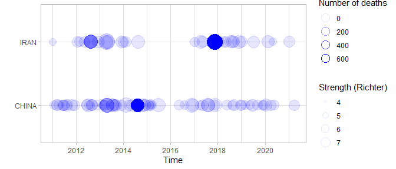

```r
ggplot2::ggplot(data = ex_data, aes(x = ex_data$DATE ,
                          y = ex_data$COUNTRY,
                          size = ex_data$EQ_PRIMARY,
                          alpha = ex_data$DEATHS)) +
 geom_timeline()+
 theme_light()+
 labs(size = "Strength (Richter)",
      alpha = "Number of deaths")+
 xlab("Time") + ylab("")
```

## geom_timeline_label

**Description** *geom_timeline_label* make labels for a timeline of earthquakes for countries

**Usage** geom_timeline_label( mapping = NULL, data = NULL, stat = “identity”, position = “identity”, na.rm = FALSE, show.legend = F, inherit.aes = TRUE, … )

**Examples**

```r
ex_data <- readr::read_delim(raw_data,
                  delim = "\t") %>%
                      eq_clean_data() %>%
                      filter(YEAR>2010) %>%
filter(COUNTRY %in% c("IRAN","CHINA"))
```

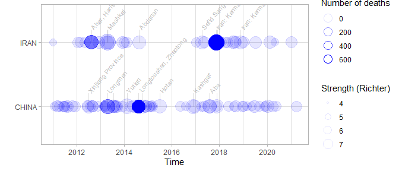

```r
ggplot2::ggplot(data = ex_data, aes(x = ex_data$DATE ,
                          y = ex_data$COUNTRY,
                          size = ex_data$EQ_PRIMARY,
                          alpha = ex_data$DEATHS,
                          label = ex_data$LOCATION_NAME)) +
 geom_timeline_label(n_max = 20)+
 geom_timeline()+
 theme_light()+
 labs(size = "Strength (Richter)",
      alpha = "Number of deaths")+
 xlab("Time") + ylab("")
```

## ggproto_timeline

**Description** *ggproto_timeline* build ggproto object for geom_timeline

**Usage** ggproto_timeline

**Format** An object of class ggproto_timeline (inherits from Geom, ggproto, gg) of length 6.

## ggproto_timeline_label

**Description** *ggproto_timeline_label* build ggproto object for geom_timeline_label

**Usage** ggproto_timeline_label

**Format** An object of class ggproto_timeline_label (inherits from Geom, ggproto, gg) of length 6.